```python
import numpy as np
import matplotlib.pyplot as plt
```

```python
N = 1000 #Population size
```

```python
exp_dist = np.random.exponential(size=(N))
```

```python
len(exp_dist)
```

```
1000
```

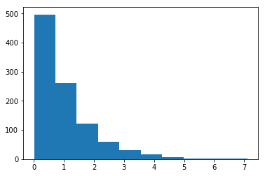

```python
plt.hist(exp_dist)
```

```python
mu = np.mean(exp_dist) #Arithmetic mean / Mean
```

```python
mu
```

```
1.0157428560988593
```

```python
sigma = np.std(exp_dist) #Standard deviation
```

```python
sigma
```

```
0.9884519895574936
```

```python
n = 20 #Sample size
```

```python
random_sample = np.random.choice(exp_dist, size=(n))
```

```python
random_sample #Random sample from exp_dist (exp_dist represents population with exponential distribution)
```

```
array([0.53872931, 0.0197284 , 1.96554926, 0.47309499, 0.24833744,
       4.0607785 , 0.27447471, 1.09646856, 1.43409915, 1.74561192,
       0.63933484, 1.2199579 , 0.09028405, 0.99246141, 4.23528476,
       0.0291618 , 1.71928406, 1.74013271, 5.12282199, 0.51545466])
```

```python
x_bar = np.mean(random_sample) #Sample mean
```

```python
x_bar
```

```
1.4080525212438313
```

```python
no_of_samples = 1000
```

```python
sample_means = [np.mean(np.random.choice(exp_dist, size=(n))) for i in range(no_of_samples)]
```

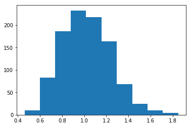

```python
plt.hist(sample_means) #Sampling distribution of the sample mean
```

Looking to latter histogram, we can see that sampling distribution of the sample mean approximately follows normal/gaussian distribution. As we increase sample size (n) and number of samples (no_of_samples) we can get better and better normal distribution. That is the first out of three main properties of Central Limit Theorem (CLT).

```python
mu_x_bar = np.mean(sample_means)
```

```python
mu_x_bar
```

```
1.0223202043062471
```

Second main property of CLT is that mean of sampling distribution of the sample mean (mu_x_bar) is equal to population mean (mu). mu = 1.0157428560988593, mu_x_bar = 1.0223202043062471.

```python
sigma_x_bar = np.std(sample_means)
```

```python
sigma_x_bar
```

```
0.22038026892439116
```

```python
sigma / np.sqrt(n)
```

```
0.22102458411454678
```

Third property of CLT is that standard deviation of sampling distribution of the sample mean (sigma_x_bar) is equal to population standard deviation (sigma) divided by square root of sample size. sigma / sqrt(20) = 0.22102458411454678, sigma_x_bar = 0.22038026892439116. Note: As we increase sample size, denominator will also increase which leads to smaller standard deviation of sampling distribution which also leads to narrower normal distribution.

One more interesting thing about CLT is that no matter what distribution of population looks like (is it normal, exponential, bimodal, uniform, laplace, etc.), its sampling distribution of the sample mean will always be normal. Only prerequisite is that we took large enough sample size. That should be at least 10.